# St. Louis Crime Analysis

## Introduction

We will be performing exploratory data analysis for three types of recorded criminal activity in the St. Louis area. The study focuses on arson, DUIs, and homicides. The purpose of this study is to answer questions about that data and gain familiarity for continuing analysis. Our methods in the analysis will use descriptive statistical techniques to answer questions, such as, “where did these crimes take place?” (Figure 5), “On average, how often are they happening?” (Figure 2 & Figure 3), and “Which crime is happening the most?” (Figure 1). Through the descriptive methods, we will be looking for unexpected results (Rogerson, 2011).

## Required R Packages

The code cell below indicates the R packages used in the analysis.

```r
#install and load packages here
library(ggplot2)
library(maptools)
library(spatstat)
library(leaflet)
library(dplyr)
library(doBy)
library(rgdal)
library(ggmap)
library(gridExtra)
library(sp)
library(RColorBrewer)
library(DT)
```

## Methods

In our analysis we are leveraging exploratory data analysis and visualization with the R programming language to gain an understanding of our chosen data set and eventually suggest a hypothesis if deemed appropriate (Rogerson, 2011). The datatable shown in Table 1 allows us to preview the selected variables and observations. The table was filtered to show crime types, and frequency per month. Further insights are gained by showing trends in total number of crimes based on category (Figure 1) and crimes per month with an overlaid density curve in Figure 2 to quickly spot heightened observations. Figure 3 separates the data based on type, month, and year. A spatial display using R Leaflet is in Figure 5 where a possible hypothesis of crime type clustering could be present. Lastly, the Descriptive Statistics section calculates the mean, median, standard deviation, and outliers for grasping a better understanding of our data.

## DataTable

```r
# set working directories
file_dir_crime <- "crime/"

# set other directories
file_dir_gis <- "gis/"

#read in crime file
#concatenate the filedircrime (set earlier to your directory) with the filename using paste()
crime_file <- paste(file_dir_crime,"crimeStLouis20132014b.csv", sep = "")
crime_file_agg <- paste(file_dir_crime,"crimeStLouis20132014b_agg.csv", sep = "")

# read data into csv
crimesstl <- read.csv(crime_file, header=TRUE,sep=",")
crimesstl_agg <- read.csv(crime_file_agg, header=TRUE,sep=",")

#create a list of the unique crime types in the data set and view what these are so that you can select using these so that you can explore their distributions.
listcrimetype <-unique(crimesstl$crimetype)

#returns a datatable of the loaded csv
sub_crime_agg <- crimesstl_agg %>%
  select(count, crimetype, month)

datatable(sub_crime_agg, width = "auto")
```

|  | count | crimetype | month |
| --- | --- | --- | --- |
| 1 | 1 | dui | 2 |
| 2 | 5 | homicide | 2 |
| 3 | 2 | arson | 9 |
| 4 | 1 | arson | 3 |
| 5 | 1 | arson | 5 |
| 6 | 1 | arson | 8 |
| 7 | 4 | dui | 10 |
| 8 | 2 | homicide | 10 |
| 9 | 1 | arson | 4 |
| 10 | 3 | arson | 11 |

[output cut: 196 more lines]

## What type of crimes occur more than others?

One might assume from observations in Table 1 that DUIs would be the highest counted crime in our study. By summing the count columns from all crimes in 2013 and 2014 we actually see that arson has the highest counted crime type in comparison to homicide an DUIs. The number for this summation and conclusion is visible in Figure 1. From this conclusion I would make an effort to understand what event took place to increase the level of arson above the number of DUIs.

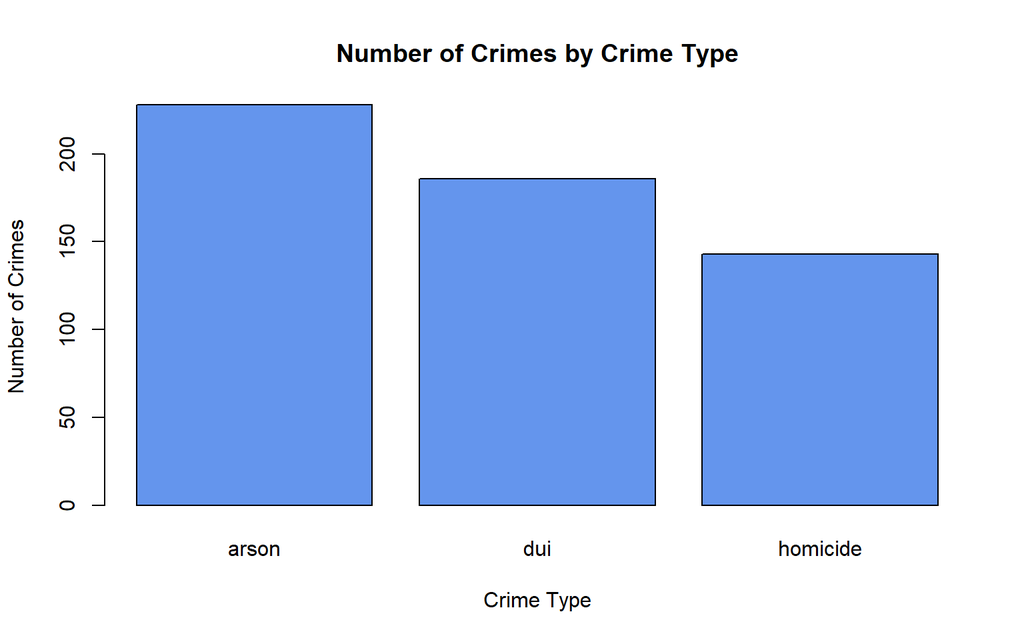

```r
#Barchart of crimes by crimetype
counts <- table(crimesstl$crimetype)
barplot(counts, col = "cornflowerblue", main = "Number of Crimes by Crime Type", xlab="Crime Type", ylab="Number of Crimes")
```

**Figure 1.** In combined years 2013 and 2014 Arson is the most common crime followed by DUI, and homicide. This chart is informative, and accurate, but may be misleading to conclude that arson is consistently more common than DUIs in St. Louis.

## Temporal patterns associated with each crime

Now let’s dive deeper into the data, and start to visualize information based on when it took place. Perhaps with understanding when the events took place, we can start to see if there is a particular reason or event that is skewing our data to a misguided interpretation. I would hypothesis in this stage of the process that an event occurred in 2013 or 2014 that led to an extreme level of arson.

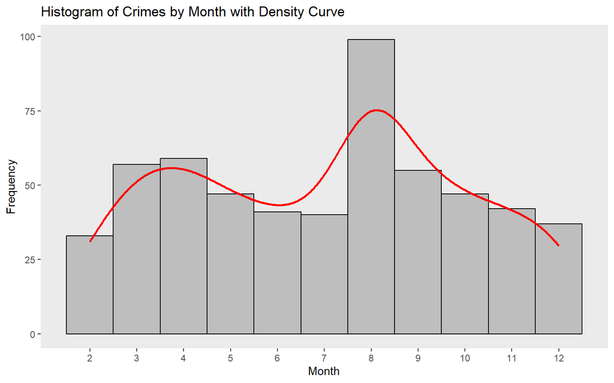

```r
#Histograms of crimes by observations per month

ggplot(crimesstl, aes(x = month)) +
  geom_histogram(binwidth = 1, fill = "grey", color = "black") +
  geom_density(aes(y = after_stat(count)), color = "red", linewidth = 1) +
  labs(title = "Histogram of Crimes by Month with Density Curve",
       x = "Month",
       y = "Frequency") +
  theme(panel.grid.major = element_blank(), panel.grid.minor = element_blank()) +
  scale_x_continuous(breaks = 2:12)
```

**Figure 2.** By combining all crime types in 2013 and 2014, most observations took place in the month of August.

Now that we have seen the population of our data summed into one chart that gives an interesting perspective that the month of august experienced an above average number of crimes. We know very little of what kind of events took place. Utilizing a facet wrapped plot based on crime type and year we can see when each category of crimes experienced peaks and troughs based on monthly intervals.

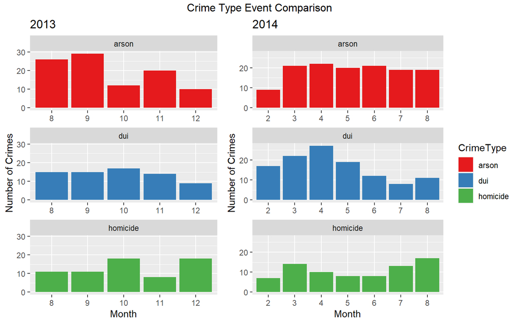

```r
crimess2013 <- subset(crimesstl, year == "2013")
crimess2014 <- subset(crimesstl, year == "2014")

counts_2013 <- table(crimess2013$month, crimess2013$crimetype)
counts_df_2013 <- as.data.frame(counts_2013)
colnames(counts_df_2013) <- c("Month", "CrimeType", "Count")

# Create the faceted barplot
plot_2013 <- ggplot(counts_df_2013, aes(x = Month, y = Count, fill = CrimeType)) +
              geom_bar(stat = "identity", show.legend = FALSE) +
              labs(title = "2013",
                   x = "Month",
                   y = "Number of Crimes") +
              scale_fill_brewer(palette = "Set1") +  # You can change the palette if needed
              facet_wrap(~ CrimeType, scales = "free_x", ncol = 1)

counts_2014 <- table(crimess2014$month, crimess2014$crimetype)
counts_df_2014 <- as.data.frame(counts_2014)
colnames(counts_df_2014) <- c("Month", "CrimeType", "Count")

# Create the faceted barplot
plot_2014 <- ggplot(counts_df_2014, aes(x = Month, y = Count, fill = CrimeType)) +
              geom_bar(stat = "identity") +
              labs(title = "2014",
                   x = "Month",
                   y = "Number of Crimes") +
              scale_fill_brewer(palette = "Set1") +  # You can change the palette if needed
              facet_wrap(~ CrimeType, scales = "free_x", ncol = 1)

grid.arrange(plot_2013, plot_2014, nrow=1,ncol=2, widths = c(.75, 1), top = "Crime Type Event Comparison")
```

**Figure 3.** Arson levels are heightened in August of 2013. The ggplot library and the facet_wrap() function was used to seperate the variables and visualize the information side by side.

## Descriptive Statistics

```r
sub_crime_agg_arson <- crimesstl_agg %>%
  filter(crimetype == 'arson') %>%
  select(count, crimetype, month)

sub_crime_agg_dui <- crimesstl_agg %>%
  filter(crimetype == 'dui') %>%
  select(count, crimetype, month)

sub_crime_agg_homicide <- crimesstl_agg %>%
  filter(crimetype == 'homicide') %>%
  select(count, crimetype, month)


arson <- summary(sub_crime_agg_arson)
df_arson <- data.frame(arson)
dfsub_arson <- df_arson %>%
  subset(select = -c(Var1)) %>%
  rename(Arson = Var2)


dui <- summary(sub_crime_agg_dui)
df_dui <- data.frame(dui)
dfsub_dui <- df_dui %>%
  subset(select = -c(Var1)) %>%
  rename(DUI = Var2)


homicide <- summary(sub_crime_agg_homicide)
df_homicide <- data.frame(homicide)
dfsub_homicide <- df_homicide %>%
  subset(select = -c(Var1)) %>%
  rename(Homicide = Var2)
```

```r
DT::datatable(dfsub_arson[1:6, ])
```

|  | Arson | Freq |
| --- | --- | --- |
| 1 | count | Min. : 1.000 |
| 2 | count | 1st Qu.: 1.000 |
| 3 | count | Median : 2.000 |
| 4 | count | Mean : 2.351 |
| 5 | count | 3rd Qu.: 3.000 |
| 6 | count | Max. :13.000 |

**Table 2.** The mean value for arson events in St. Louis is 2.351 and above the median value of 2.0 with a Q75 value of 3.0. Since the mean is above the average, the data is skewed to the right.

By calculating the descriptive statistics for arson we can reveal that the high value events in August and September of 2013 are outlier events and far above the average. In attempt to clarify how far above average the outlier values are, the standard deviation for arson counts across 2013 and 2014 is 2.13. Making certain months that reached 10 to 13 counts 3.56 and 5 deviations from the mean. The overall spread of values for arson are relatively tight, but certain months with high values attempts to convince you that arson is more common than DUIs.

```r
DT::datatable(dfsub_dui[1:6, ])
```

|  | DUI | Freq |
| --- | --- | --- |
| 1 | count | Min. : 1.000 |
| 2 | count | 1st Qu.: 1.000 |
| 3 | count | Median : 2.000 |
| 4 | count | Mean : 2.862 |
| 5 | count | 3rd Qu.: 4.000 |
| 6 | count | Max. :20.000 |

**Table 3.** DUIs reveal and average of 2.86 per month for 2013 and 2014. Once again, another data set right skewed with an average above the median.

Boxplots are informative diagrams that allow us to see the quartile ranges (Q1, Q2 - Median, and Q3), the low and high end the range, and outliers in the data. IQR is determined by Q3 - Q1, and values that exist below Q1 − 1.5(IQR) as well as values above Q3 + 1.5(IQR) are deemed as outliers. All crime types are right skewed with outliers existing above the high range.

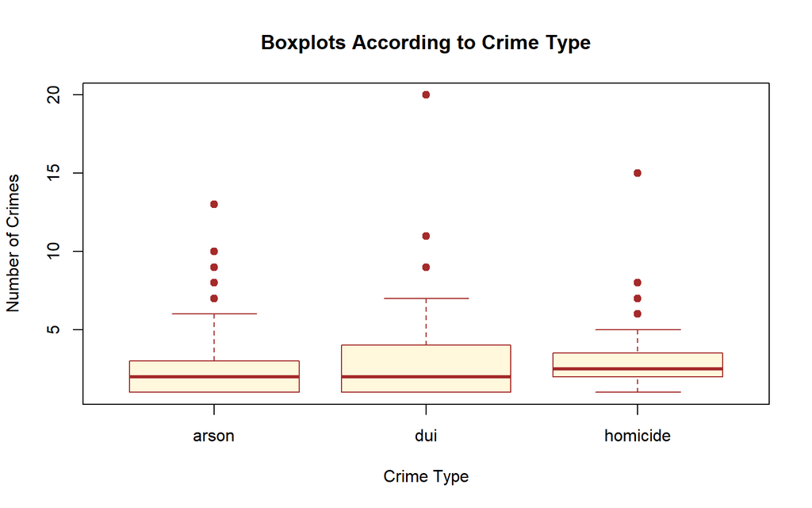

```r
#BoxPlots are useful for comparing data.
#Use the dataset crimeStLouis20132014b_agg.csv.
#These data are aggregated by neighbourhood.
agg_crime_file <-paste(file_dir_crime,"crimeStLouis20132014b_agg.csv", sep = "")
#check everything worked ok with accessing the file
#file.exists(agg_crime_file)
crimesstlagg <- read.csv(agg_crime_file, header=TRUE,sep=",")

#Compare crimetypes
boxplot(count~crimetype, data=crimesstlagg,main="Boxplots According to Crime Type",
            xlab="Crime Type", ylab="Number of Crimes",
            col="cornsilk", border="brown", pch=19)
```

**Figure 4.** Median values are represented by the thick brown line in the center of the boxplot. We see the outliers for all crime types well above the highest whisker. The plot does reveal an interesting point that the median value for homicides in 2013 and 2014 is higher than the median values for arson and DUIs, which I would not have predicted.

## Where did the crimes take place?

Diplaying point location based on attributes might allow us to create potential hypothesis if location is a determining factor for the results we have seen so far. Clusters of crime type can be seen across St. Louis in Figure 5 below.

##### Spatial Data Visualization

```r
#This will create a map with all of the points
gis_file <- paste(file_dir_gis,"stl_boundary_ll.shp", sep="")
#Read the St Louis Boundary Shapefile
StLouisBND <- readOGR(gis_file, layer = "stl_boundary_ll", GDAL1_integer64_policy = FALSE, verbose = FALSE)

crimess22 <- subset(crimesstl, crimetype == "arson")
crimess33 <- subset(crimesstl, crimetype == "dui")
crimess44 <- subset(crimesstl, crimetype == "homicide")

#Create an interactive map for each crimetype
#To view a particular crime you will want to create a map using a subset of the data.
#Or use leaflet and include a background map to put the crime in context.

leaflet(crimesstl) %>%
  addTiles() %>%
  addPolygons(data=StLouisBND,
              color = "#444444",
              weight = 3,
              smoothFactor = 0.5,
              opacity = 1.0,
              fillOpacity = 0.5,
              fill= FALSE,
              highlightOptions = highlightOptions(color = "white", weight = 2,
                                                      bringToFront = TRUE),
              group='St. Louis') %>%

  addCircles(data = crimess22,
             color = "red",
             lng = crimess22$xL,
             lat = crimess22$yL,
             weight = 5,
             radius = 10,
             group = "Arson",
    popup = paste0("Crime type: ", as.character(crimess22$crimetype),
                              "; Month: ", as.character(crimess22$month)))  %>%


#Turn these on when you are ready to view them. To do so remove the # and switch off the addCircles above by adding a #
  addCircles(data = crimess33,
             color = "blue",
             lng = crimess33$xL,
             lat = crimess33$yL,
             weight = 5,
             radius = 10,
             group = 'DUI',
      popup = paste0("Crime type: ", as.character(crimess33$crimetype),
                                "; Month: ", as.character(crimess33$month)))  %>%

  addCircles(data = crimess44,
             color = "green",
             lng = crimess44$xL,
             lat = crimess44$yL,
             weight = 5,
             radius = 10,
             group = 'Homicide',
      popup = paste0("Crime type: ", as.character(crimess44$crimetype),
                                "; Month: ", as.character(crimess44$month)))  %>%

  addLayersControl(
          overlayGroups =c('St. Louis', 'Arson', 'DUI', 'Homicide'),
          options = layersControlOptions(collapsed=FALSE)
          ) %>%

  addLegend("bottomleft",
           colors = c("#444444", "red", "blue", "green"),
           labels = c("St. Louis", "Arson", "DUI", "Homicide"),
           title = "Crime Type",
           opacity = 1
  )
```

[interactive chart not shown]

**Figure 5.** Strong spatial dependence is portrayed in arson and homicides, while the opposite is viewed for DUIs.

Spatial dependent patterns for arson and homicide might lead us to hypothesize an underlying reason for the clustering of events. DUIs on the other hand lack spatial dependence and the variation is more dispersed across the city. Therefore spatial autocorrelation could potentially be hypothesized as high regarding arson and homicides, and low for DUIs.

## References

Rogerson, P.A. (2011), Statistical Methods for Geography